# STAC67 Final Project Report

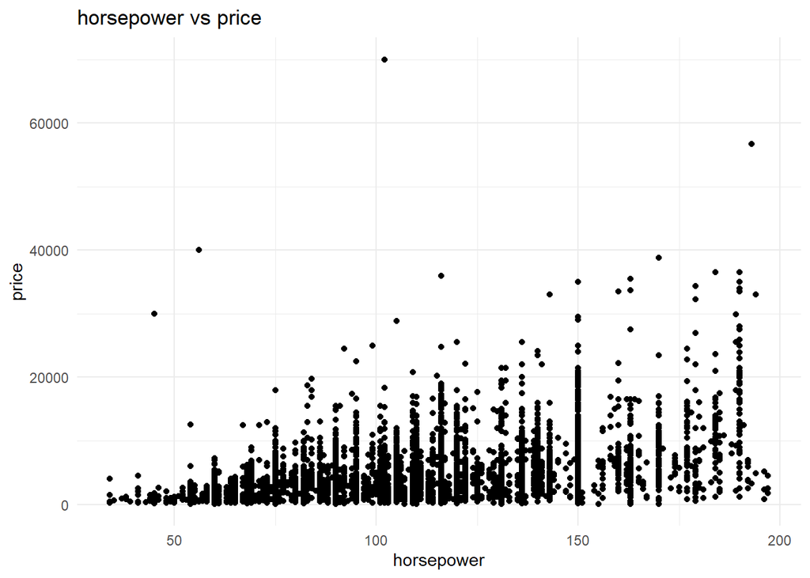

```r
ggplot(clean_hp, aes(x = horsepower, y = price)) + geom_point() +
  theme_minimal() + ggtitle("horsepower vs price")
```

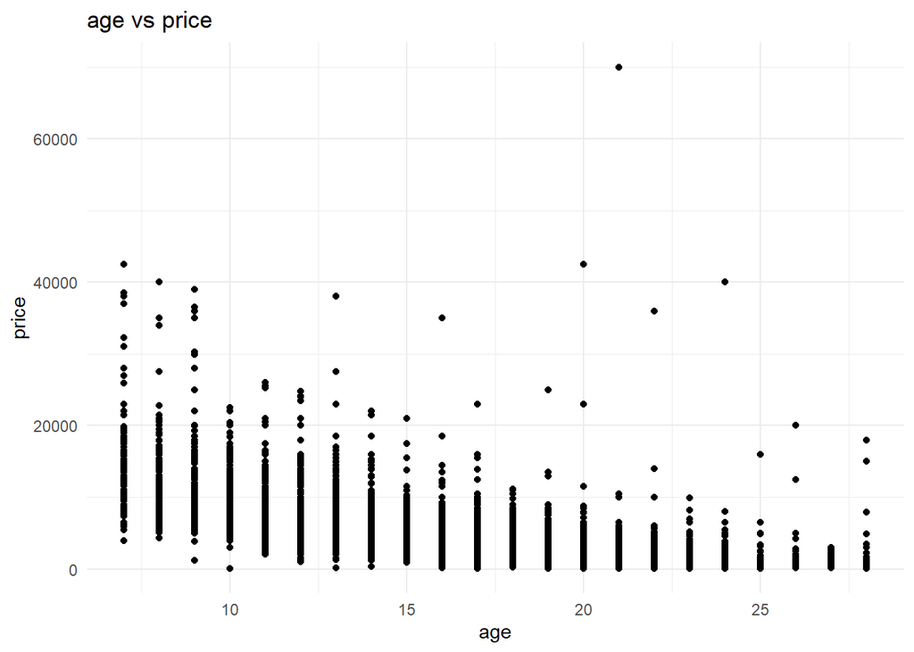

```r
ggplot(clean_age, aes(x = age, y = price)) + geom_point() +
  theme_minimal() + ggtitle("age vs price")
```

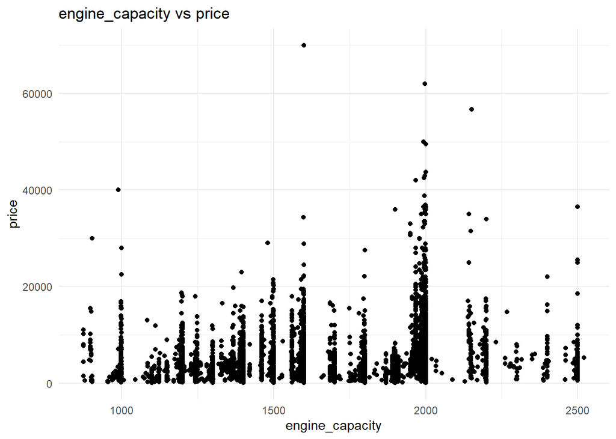

```r
ggplot(clean_ec, aes(x = engine_capacity, y = price)) + geom_point() +
  theme_minimal() + ggtitle("engine_capacity vs price")
```

```r
#cleaning for car mileage
model <- lm(price ~ car_mileage, data = clean_data)

# leverage points (outliers in x) removal
leverage <- hatvalues(model)
threshold <- 2 * length(coef(model)) / nrow(clean_data)
leverage_points <- which(leverage > threshold | leverage > 0.5)
# clean_cm_data filters out for car_mileage ONLY.
# This way we can still do comprehensive analysis on other predictors
clean_cm_data <- clean_data[-leverage_points, ]

# trimming x-axis data, will cause bias. note: 84(?) values removed
clean_cm_data <- subset(clean_cm_data, car_mileage <= 750000)

# outliers in y removal
n <- nrow(clean_data)
print(n)
```

```
## [1] 7076
```

```r
# considering p'=2 (intercept and car_mileage), could be wrong -- double check
threshold <- qt(1 - (0.05/(2*n)), n-2-1)
print(threshold)
```

```
## [1] 4.495051
```

```r
studentized_residuals <- rstudent(model)
outlier_indices <- which(abs(studentized_residuals) > threshold)
clean_cm_data <- clean_cm_data[-outlier_indices, ]

#cleaning for horsepower
model <- lm(price ~ horsepower, data = clean_data)

# leverage points (outliers in x) removal
leverage <- hatvalues(model)
threshold <- 2 * length(coef(model)) / nrow(clean_data)
leverage_points <- which(leverage > threshold | leverage > 0.5)
clean_hp_data <- clean_data[-leverage_points, ]

#clean_hp_data <- subset(clean_data, price <= 60000) # trimming y-axis data, will cause bias.

# outliers in y removal
n <- nrow(clean_data)
print(n)
```

```
## [1] 7076
```

```r
# considering p'=2 (intercept and horsepower), could be wrong -- double check
threshold <- qt(1 - (0.05/(2*n)), n-2-1)
print(threshold)
```

```
## [1] 4.495051
```

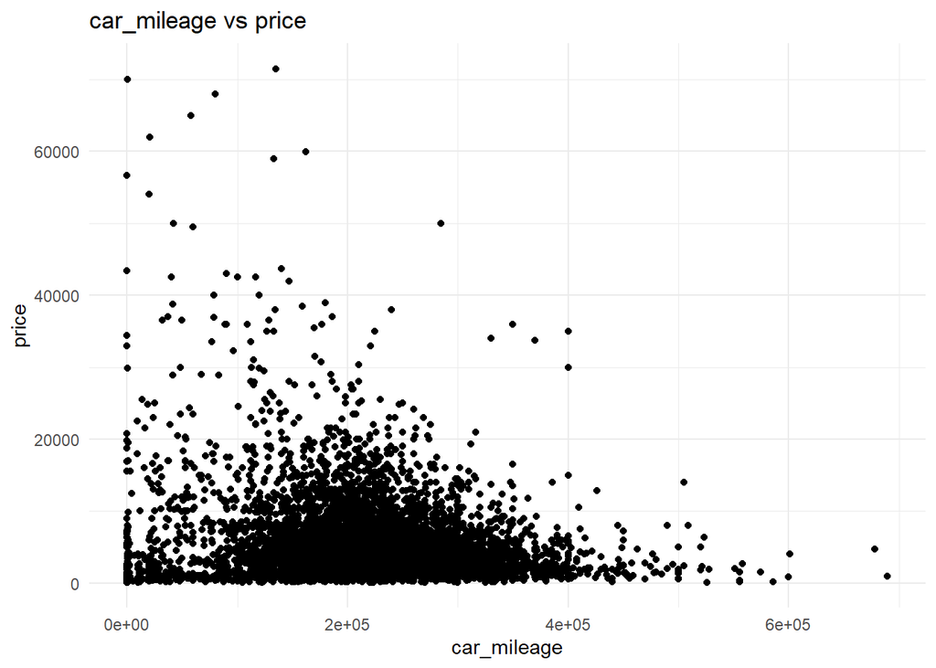

```r
studentized_residuals <- rstudent(model)
outlier_indices <- which(abs(studentized_residuals) > threshold)
clean_hp_data <- clean_hp_data[-outlier_indices, ]

# TO DO: (?) should we repeat this process for the other continuous variables?

ggplot(clean_cm_data, aes(x = car_mileage, y = price)) + geom_point() +
  theme_minimal() + ggtitle("car_mileage vs price")
```

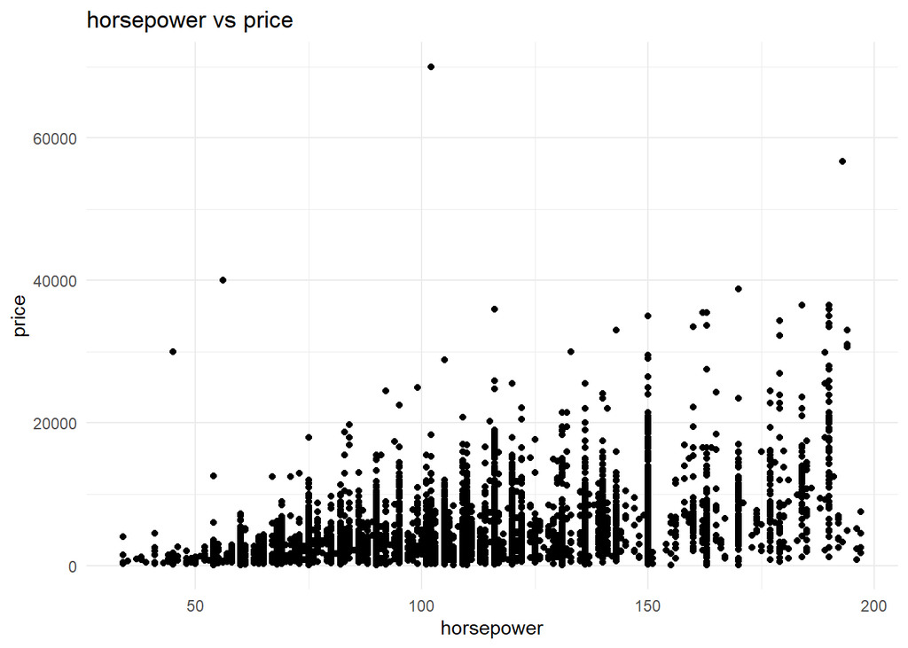

```r
ggplot(clean_hp_data, aes(x = horsepower, y = price)) + geom_point() +
  theme_minimal() + ggtitle("horsepower vs price")
```

After outlier cleaning, let’s check on the scatter plots again to see if these continuous variables have a significant influence on the car price:

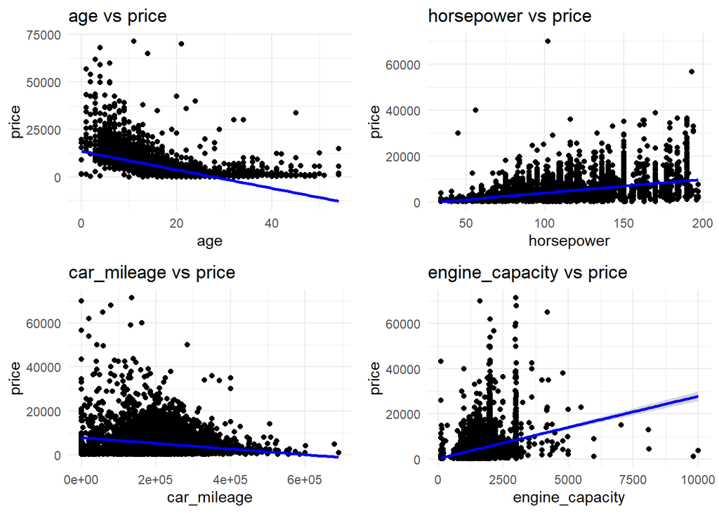

```r
p1 <- ggplot(clean_data, aes(x = age, y = price)) + geom_point() +
  geom_smooth(method = "lm", se = TRUE, color = "blue") + theme_minimal() +
  ggtitle("age vs price")
p2 <- ggplot(clean_hp_data, aes(x = horsepower, y = price)) + geom_point() +
  geom_smooth(method = "lm", se = TRUE, color = "blue") + theme_minimal() +
  ggtitle("horsepower vs price")
p3 <- ggplot(clean_cm_data, aes(x = car_mileage, y = price)) + geom_point() +
  geom_smooth(method = "lm", se = TRUE, color = "blue") + theme_minimal() +
  ggtitle("car_mileage vs price") # needs outlier removed
p4 <- ggplot(clean_data, aes(x = engine_capacity, y = price)) + geom_point() +
  geom_smooth(method = "lm", se = TRUE, color = "blue") + theme_minimal() +
  ggtitle("engine_capacity vs price")
grid.arrange(p1,p2,p3,p4,ncol=2)
```

```r
model <- lm(price ~ age, data = clean_data)
summary(model)
```

```
##
## Call:
## lm(formula = price ~ age, data = clean_data)
##
## Residuals:
##    Min     1Q Median     3Q    Max
## -12321  -2260  -1167    664  66673
##
## Coefficients:
##              Estimate Std. Error t value Pr(>|t|)
## (Intercept) 13544.388    156.228   86.70   <2e-16 ***
## age          -486.547      8.352  -58.26   <2e-16 ***
## ---
## Signif. codes:  0 '***' 0.001 '**' 0.01 '*' 0.05 '.' 0.1 ' ' 1
##
## Residual standard error: 4644 on 7074 degrees of freedom
## Multiple R-squared:  0.3242, Adjusted R-squared:  0.3241
## F-statistic:  3394 on 1 and 7074 DF,  p-value: < 2.2e-16
```

```r
model <- lm(price ~ horsepower, data = clean_hp_data)
summary(model)
```

```
##
## Call:
## lm(formula = price ~ horsepower, data = clean_hp_data)
##
## Residuals:
##    Min     1Q Median     3Q    Max
##  -8851  -2410   -736   1214  65890
##
## Coefficients:
##              Estimate Std. Error t value Pr(>|t|)
## (Intercept) -1903.618    172.421  -11.04   <2e-16 ***
## horsepower     58.953      1.503   39.23   <2e-16 ***
## ---
## Signif. codes:  0 '***' 0.001 '**' 0.01 '*' 0.05 '.' 0.1 ' ' 1
##
## Residual standard error: 4080 on 6679 degrees of freedom
## Multiple R-squared:  0.1873, Adjusted R-squared:  0.1872
## F-statistic:  1539 on 1 and 6679 DF,  p-value: < 2.2e-16
```

```r
model <- lm(price ~ car_mileage, data = clean_cm_data)
summary(model)
```

```
##
## Call:
## lm(formula = price ~ car_mileage, data = clean_cm_data)
##
## Residuals:
##    Min     1Q Median     3Q    Max
##  -7729  -2944  -1307   1231  65420
##
## Coefficients:
##               Estimate Std. Error t value Pr(>|t|)
## (Intercept)  7.829e+03  1.854e+02   42.22   <2e-16 ***
## car_mileage -1.295e-02  7.916e-04  -16.36   <2e-16 ***
## ---
## Signif. codes:  0 '***' 0.001 '**' 0.01 '*' 0.05 '.' 0.1 ' ' 1
##
## Residual standard error: 5434 on 6955 degrees of freedom
## Multiple R-squared:  0.03705,    Adjusted R-squared:  0.03691
## F-statistic: 267.6 on 1 and 6955 DF,  p-value: < 2.2e-16
```

```r
model <- lm(price ~ engine_capacity, data = clean_data)
summary(model)
```

```
##
## Call:
## lm(formula = price ~ engine_capacity, data = clean_data)
##
## Residuals:
##    Min     1Q Median     3Q    Max
## -26213  -3036  -1428   1230  65319
##
## Coefficients:
##                 Estimate Std. Error t value Pr(>|t|)
## (Intercept)     272.7652   232.8749   1.171    0.242
## engine_capacity   2.7550     0.1295  21.278   <2e-16 ***
## ---
## Signif. codes:  0 '***' 0.001 '**' 0.01 '*' 0.05 '.' 0.1 ' ' 1
##
## Residual standard error: 5476 on 7074 degrees of freedom
## Multiple R-squared:  0.06015,    Adjusted R-squared:  0.06002
## F-statistic: 452.8 on 1 and 7074 DF,  p-value: < 2.2e-16
```

Now moving on to the categorical variables.

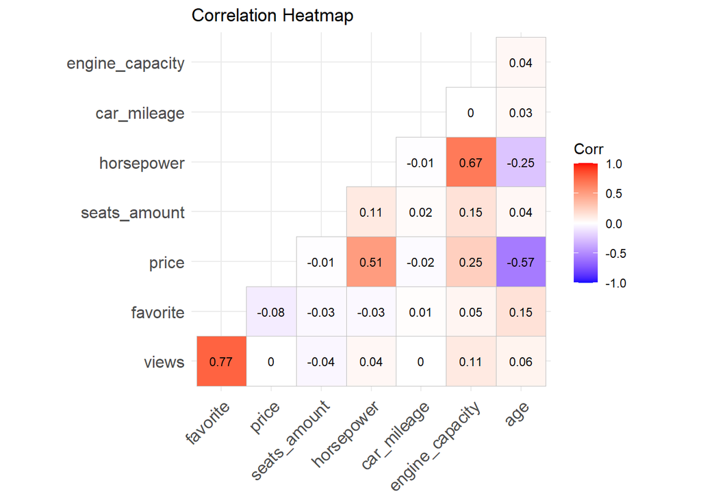

```r
# Select numeric predictors only
numeric_data <- clean_data[sapply(clean_data, is.numeric)]

# Remove specific variables like 'Year'
numeric_data <- numeric_data[, !names(numeric_data) %in% c("year")]

# Compute correlation matrix
cor_matrix <- cor(numeric_data, use = "complete.obs")

# Plot correlation matrix with ggcorrplot
ggcorrplot(
  cor_matrix,
  method = "square",       # Style of the plot
  type = "lower",          # Show lower triangular correlation matrix
  lab = TRUE,              # Display correlation values inside the cells
  lab_size = 3,            # Adjust size of labels
  title = "Correlation Heatmap",  # Add a title
  colors = c("blue", "white", "red") # Define color gradient (negative, neutral, positive correlations)
)
```

[Note: based off of this correlation map: - Remove one of views/favourites since this has strong correlation (but I think we’re getting rid of both anyways) - Ensure no multicollinearity between horsepower and engine_capacity (VIF?) - Check to see if we can remove seats_amount and car_mileage from the model since they don’t give much information on price it looks like - this is just a little suspicious since usually more mileage should mean cheaper car? just make sure to do lots of investigation before removing it.]

Before we delve further into data analysis, we notice that there’s some information in our dataset that is unlikely to be relevant, such as how many views or favourites the car posting gets, or the date of which it was posted. However, we need to run a t-test to make sure that those variables indeed do not have any influence on the final price of the car.

## Categorical Vairable Analysis

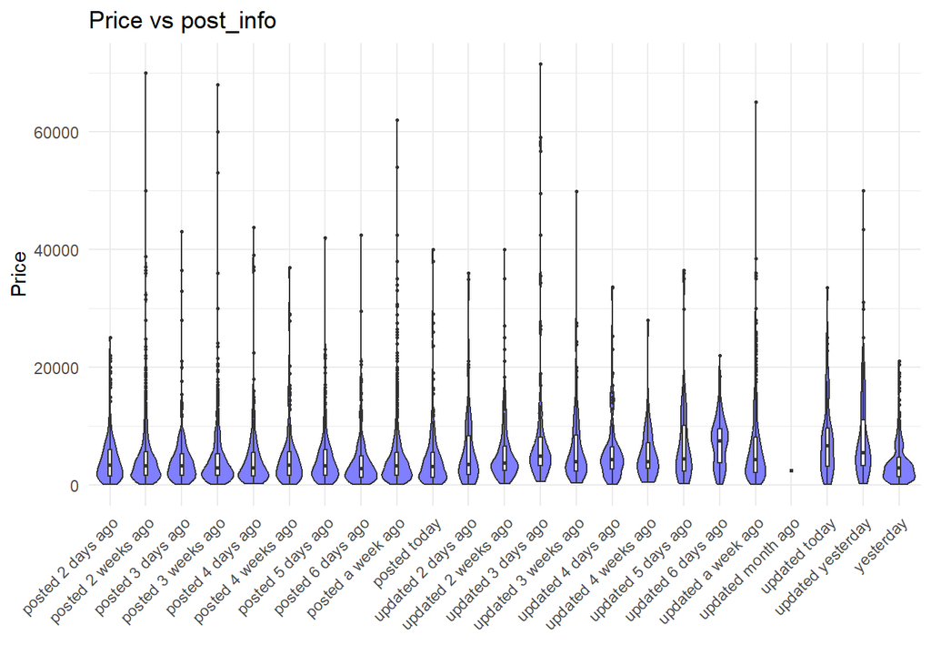

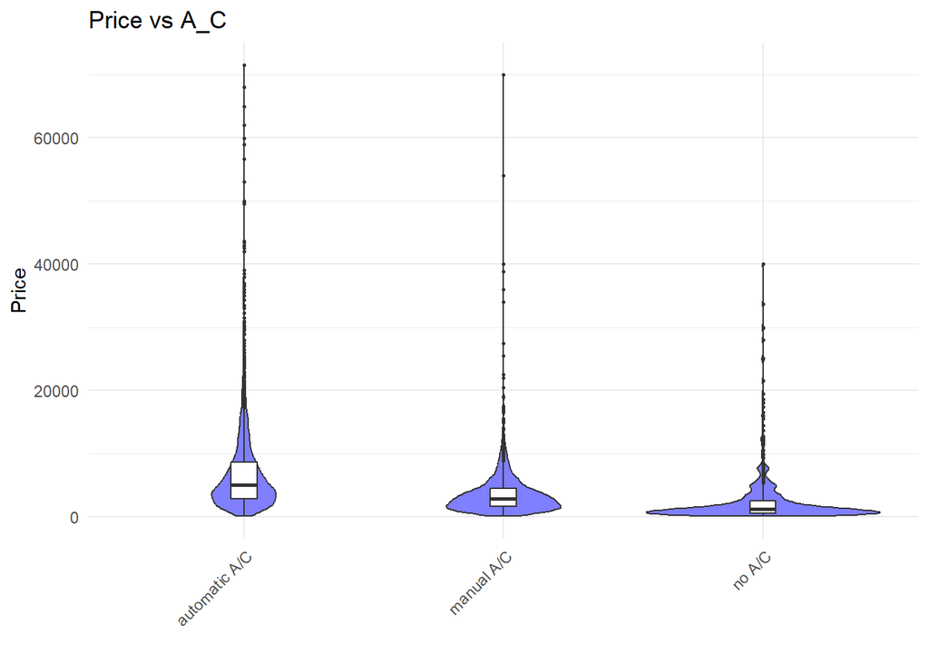

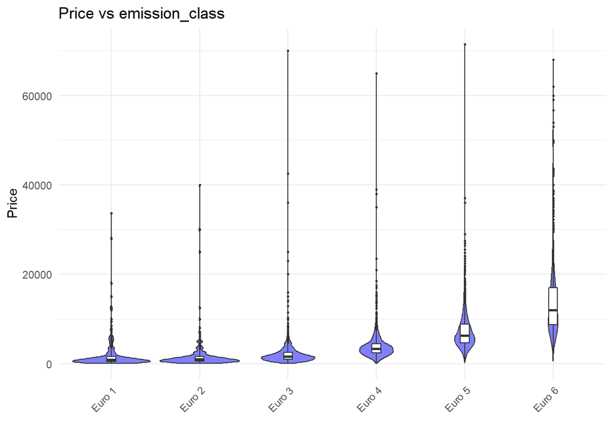

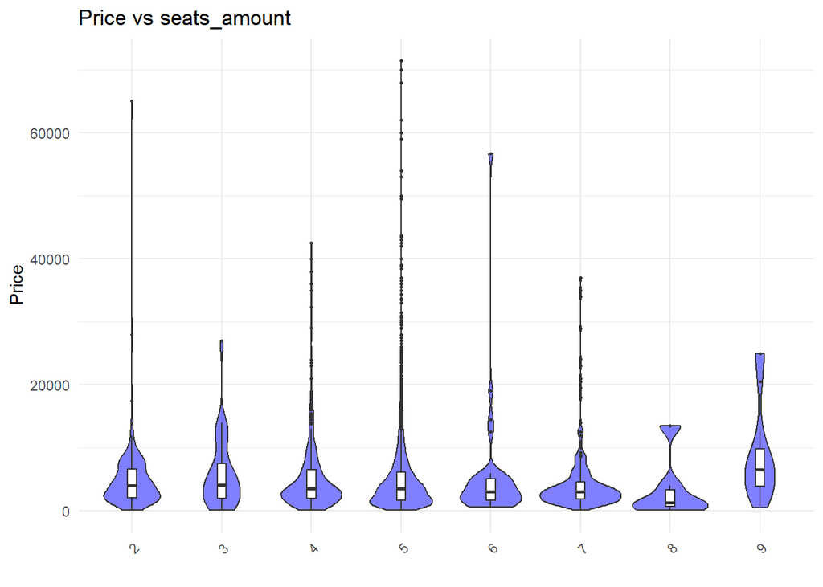

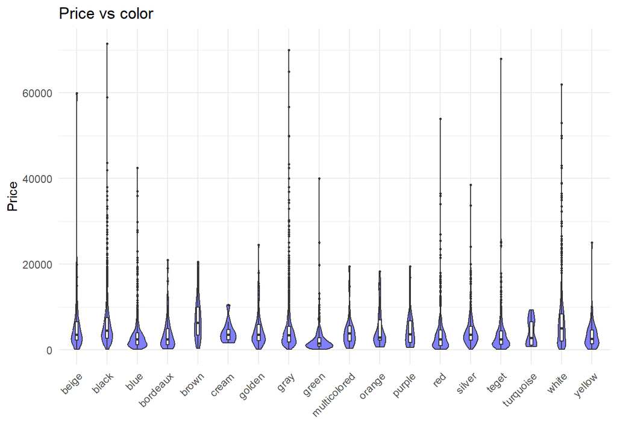

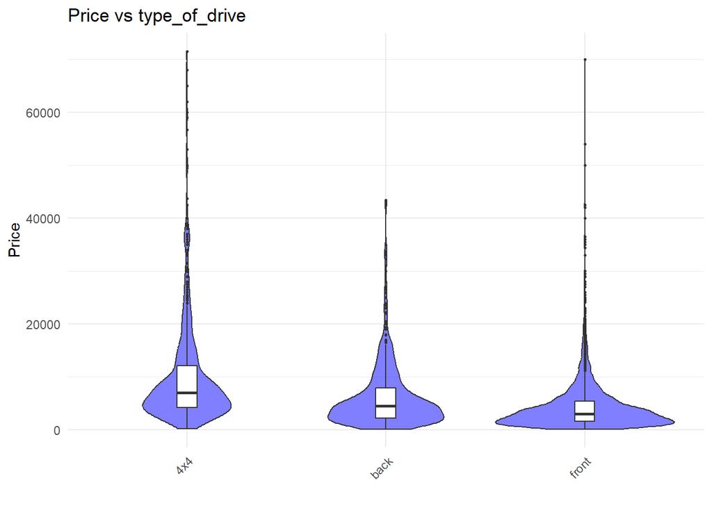

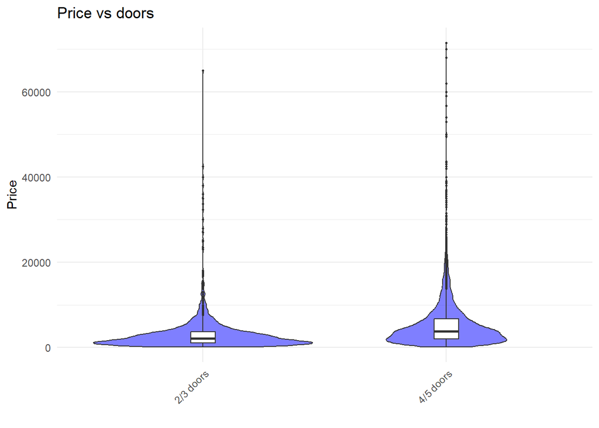

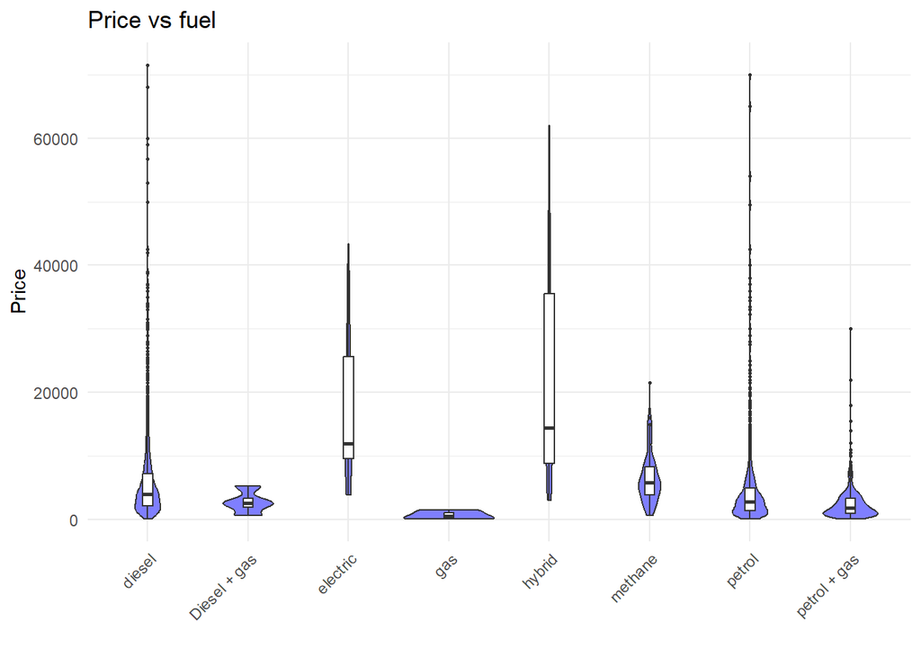

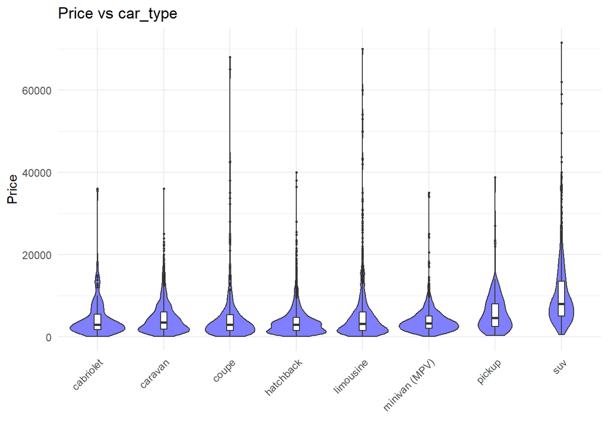

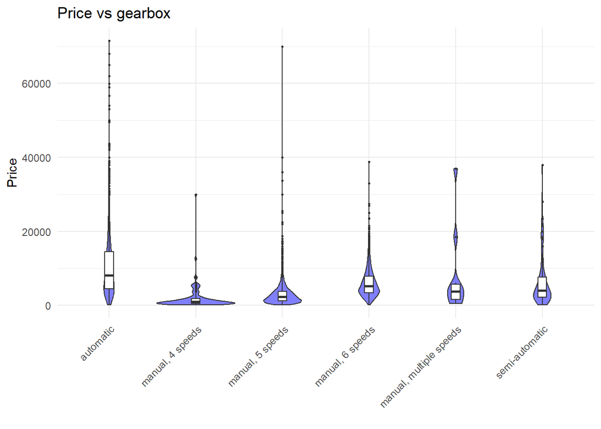

```r
# List of all categorical variables
categorical_vars <- c("post_info", "A_C", "emission_class", "seats_amount",
                      "color", "type_of_drive", "doors", "fuel",
                      "car_type", "gearbox")

# Create individual plots for each categorical variable
for (var in categorical_vars) {

  # Filter non-empty data for the current variable
  non_empty_data <- clean_data[!is.na(clean_data[[var]]) & !is.na(clean_data$price), ]

  # Check if the variable is a factor; if not, convert it
  if (!is.factor(non_empty_data[[var]])) {
    non_empty_data[[var]] <- as.factor(non_empty_data[[var]])
  }

  # Create the violin + box plot
  plot <- ggplot(non_empty_data, aes(x = .data[[var]], y = price)) +
    geom_violin(fill = "blue", alpha = 0.5) +
    geom_boxplot(width = 0.1, fill = "white", outlier.size = 0.5) +
    labs(title = paste("Price vs", var), y = "Price", x = "") +
    theme_minimal() +
    theme(axis.text.x = element_text(angle = 45, hjust = 1))
    print(plot)
}
```

## Model

```r
# List of all the variables to include in the model
categorical_vars <- c("post_info", "A_C", "emission_class", "seats_amount",
                      "color", "type_of_drive", "doors", "fuel",
                      "car_type", "gearbox")

# Convert categorical variables to factors
clean_data[categorical_vars] <- lapply(clean_data[categorical_vars], as.factor)

# Check if columns like car_name are factors or should be treated as character (if needed)
# Here we assume "car_name" is a unique identifier, so it should be excluded from the model
clean_data$car_name <- as.factor(clean_data$car_name)

# Fit the full linear model (including all variables except car_name as a unique identifier)
full_model <- lm(price ~ views + favorite + post_info + year + A_C + emission_class +
                 seats_amount + horsepower + color + car_mileage + engine_capacity +
                 type_of_drive + doors + fuel + car_type + gearbox, data = clean_data)

# Summary of the model to see the coefficients and performance
summary(full_model)
```

```
##
## Call:
## lm(formula = price ~ views + favorite + post_info + year + A_C +
##     emission_class + seats_amount + horsepower + color + car_mileage +
##     engine_capacity + type_of_drive + doors + fuel + car_type +
##     gearbox, data = clean_data)
##
## Residuals:
##    Min     1Q Median     3Q    Max
## -27162  -1269    -46   1000  68001
##
## Coefficients:
##                                  Estimate Std. Error t value Pr(>|t|)
## (Intercept)                    -6.070e+05  2.515e+04 -24.132  < 2e-16 ***
## views                           1.824e-01  7.500e-02   2.433 0.015013 *
## favorite                       -6.657e+01  1.315e+01  -5.062 4.26e-07 ***
## post_infoposted 2 weeks ago     1.482e+02  2.147e+02   0.690 0.490078
## post_infoposted 3 days ago      1.334e+02  2.780e+02   0.480 0.631388
## post_infoposted 3 weeks ago     3.696e+01  2.175e+02   0.170 0.865054
## post_infoposted 4 days ago      2.458e+02  2.821e+02   0.871 0.383614
## post_infoposted 4 weeks ago    -8.865e+01  2.991e+02  -0.296 0.766959
## post_infoposted 5 days ago      1.593e+02  2.739e+02   0.582 0.560797
## post_infoposted 6 days ago      1.597e+02  2.965e+02   0.539 0.590058
## post_infoposted a week ago      1.104e+02  2.052e+02   0.538 0.590748
## post_infoposted today           4.449e+02  2.715e+02   1.639 0.101313
## post_infoupdated 2 days ago     4.510e+01  3.875e+02   0.116 0.907351
## post_infoupdated 2 weeks ago    2.826e+02  2.836e+02   0.997 0.318926
## post_infoupdated 3 days ago     1.984e+03  3.867e+02   5.131 2.96e-07 ***
## post_infoupdated 3 weeks ago    5.158e+02  3.170e+02   1.627 0.103829
## post_infoupdated 4 days ago     4.263e+02  3.720e+02   1.146 0.251812
## post_infoupdated 4 weeks ago   -8.343e+02  5.571e+02  -1.497 0.134323
## post_infoupdated 5 days ago     5.932e+02  4.052e+02   1.464 0.143243
## post_infoupdated 6 days ago    -9.040e+02  3.528e+02  -2.562 0.010423 *
## post_infoupdated a week ago     4.476e+02  2.395e+02   1.869 0.061662 .
## post_infoupdated month ago      9.674e+00  3.332e+03   0.003 0.997684
## post_infoupdated today          2.903e+02  4.703e+02   0.617 0.537151
## post_infoupdated yesterday      7.466e+02  3.881e+02   1.924 0.054430 .
## post_infoyesterday              2.307e+01  2.638e+02   0.087 0.930302
## year                            3.052e+02  1.258e+01  24.252  < 2e-16 ***
## A_Cmanual A/C                  -1.910e+02  9.952e+01  -1.920 0.054959 .
```

[output cut: 46 more lines]

```
## car_typelimousine              -9.043e+01  3.826e+02  -0.236 0.813138
## car_typeminivan (MPV)          -6.544e+02  4.035e+02  -1.622 0.104836
## car_typepickup                  3.507e+02  4.848e+02   0.723 0.469458
## car_typesuv                     1.200e+03  4.108e+02   2.920 0.003506 **
## gearboxmanual, 4 speeds         1.717e+03  4.046e+02   4.244 2.23e-05 ***
## gearboxmanual, 5 speeds        -1.229e+03  1.618e+02  -7.596 3.44e-14 ***
## gearboxmanual, 6 speeds        -1.683e+03  1.409e+02 -11.944  < 2e-16 ***
## gearboxmanual, multiple speeds -1.195e+03  1.063e+03  -1.124 0.261000
## gearboxsemi-automatic          -2.851e+02  4.050e+02  -0.704 0.481586
## ---
## Signif. codes:  0 '***' 0.001 '**' 0.01 '*' 0.05 '.' 0.1 ' ' 1
##
## Residual standard error: 3316 on 6994 degrees of freedom
## Multiple R-squared:  0.6594, Adjusted R-squared:  0.6555
## F-statistic: 167.2 on 81 and 6994 DF,  p-value: < 2.2e-16
```

```r
# Check for multicollinearity (VIF - Variance Inflation Factor)
vif(full_model)
```

```
##                     GVIF Df GVIF^(1/(2*Df))
## views           2.679640  1        1.636961
## favorite        2.753326  1        1.659315
## post_info       1.734536 22        1.012595
## year            4.454135  1        2.110482
## A_C             2.218061  2        1.220375
## emission_class  5.907211  5        1.194368
## seats_amount    3.219628  7        1.087106
## horsepower      2.997857  1        1.731432
## color           1.720354 17        1.016085
## car_mileage     1.008023  1        1.004003
## engine_capacity 2.526592  1        1.589526
## type_of_drive   2.532844  2        1.261543
## doors           1.797410  1        1.340675
## fuel            1.994162  7        1.050537
## car_type        8.257759  7        1.162760
## gearbox         3.532257  5        1.134502
```

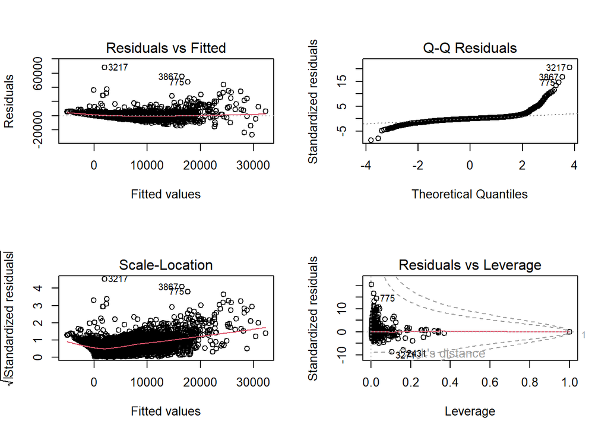

```r
# Diagnostics: Check residuals for any patterns
par(mfrow = c(2, 2))  # Multiple plots in one window
plot(full_model)
```

```r
step = stepAIC(full_model, trace = FALSE, direction = "backward")
step$anova
```

| Step | Df | Deviance | Resid. Df | Resid. Dev | AIC |
| --- | --- | --- | --- | --- | --- |
|  | NA | NA | 6994 | 76883584777 | 114802.9 |
| - color | 17 | 207259338.9 | 7011 | 77090844115 | 114788.0 |
| - car_mileage | 1 | 370832.3 | 7012 | 77091214948 | 114786.0 |
| - doors | 1 | 1250094.6 | 7013 | 77092465042 | 114784.1 |

```r
final_model = lm(price ~ views + favorite + post_info + year + A_C + emission_class +
                   seats_amount + horsepower + engine_capacity + type_of_drive + fuel +
                   car_type + gearbox, data = clean_data)
summary(final_model)
```

```
##
## Call:
## lm(formula = price ~ views + favorite + post_info + year + A_C +
##     emission_class + seats_amount + horsepower + engine_capacity +
##     type_of_drive + fuel + car_type + gearbox, data = clean_data)
##
## Residuals:
##    Min     1Q Median     3Q    Max
## -27233  -1267    -52    993  68020
##
## Coefficients:
##                                  Estimate Std. Error t value Pr(>|t|)
## (Intercept)                    -6.088e+05  2.495e+04 -24.402  < 2e-16 ***
## views                           1.807e-01  7.484e-02   2.415 0.015779 *
## favorite                       -6.685e+01  1.314e+01  -5.089 3.69e-07 ***
## post_infoposted 2 weeks ago     1.739e+02  2.144e+02   0.811 0.417345
## post_infoposted 3 days ago      1.480e+02  2.775e+02   0.533 0.593949
## post_infoposted 3 weeks ago     4.120e+01  2.173e+02   0.190 0.849656
## post_infoposted 4 days ago      2.607e+02  2.816e+02   0.926 0.354662
## post_infoposted 4 weeks ago    -8.538e+01  2.989e+02  -0.286 0.775160
## post_infoposted 5 days ago      1.557e+02  2.736e+02   0.569 0.569465
## post_infoposted 6 days ago      1.429e+02  2.962e+02   0.482 0.629523
## post_infoposted a week ago      1.244e+02  2.050e+02   0.607 0.544030
## post_infoposted today           4.406e+02  2.712e+02   1.625 0.104261
## post_infoupdated 2 days ago     9.071e+01  3.870e+02   0.234 0.814682
## post_infoupdated 2 weeks ago    3.004e+02  2.831e+02   1.061 0.288646
## post_infoupdated 3 days ago     1.996e+03  3.862e+02   5.168 2.43e-07 ***
## post_infoupdated 3 weeks ago    5.270e+02  3.165e+02   1.665 0.095973 .
## post_infoupdated 4 days ago     4.269e+02  3.714e+02   1.150 0.250389
## post_infoupdated 4 weeks ago   -8.353e+02  5.565e+02  -1.501 0.133387
## post_infoupdated 5 days ago     6.224e+02  4.041e+02   1.540 0.123533
## post_infoupdated 6 days ago    -8.916e+02  3.518e+02  -2.534 0.011284 *
## post_infoupdated a week ago     4.686e+02  2.392e+02   1.959 0.050167 .
## post_infoupdated month ago     -8.507e+01  3.326e+03  -0.026 0.979597
## post_infoupdated today          3.135e+02  4.700e+02   0.667 0.504737
## post_infoupdated yesterday      7.912e+02  3.877e+02   2.041 0.041319 *
## post_infoyesterday              5.187e+01  2.635e+02   0.197 0.843936
## year                            3.053e+02  1.248e+01  24.475  < 2e-16 ***
## A_Cmanual A/C                  -1.877e+02  9.928e+01  -1.891 0.058694 .
## A_Cno A/C                       6.444e+02  1.608e+02   4.008 6.20e-05 ***
```

[output cut: 26 more lines]

```
## car_typelimousine              -1.311e+01  3.702e+02  -0.035 0.971752
## car_typeminivan (MPV)          -5.726e+02  3.912e+02  -1.464 0.143353
## car_typepickup                  4.462e+02  4.748e+02   0.940 0.347369
## car_typesuv                     1.269e+03  4.007e+02   3.168 0.001544 **
## gearboxmanual, 4 speeds         1.769e+03  4.027e+02   4.393 1.13e-05 ***
## gearboxmanual, 5 speeds        -1.219e+03  1.615e+02  -7.550 4.92e-14 ***
## gearboxmanual, 6 speeds        -1.681e+03  1.408e+02 -11.941  < 2e-16 ***
## gearboxmanual, multiple speeds -1.254e+03  1.060e+03  -1.183 0.236816
## gearboxsemi-automatic          -2.800e+02  4.041e+02  -0.693 0.488412
## ---
## Signif. codes:  0 '***' 0.001 '**' 0.01 '*' 0.05 '.' 0.1 ' ' 1
##
## Residual standard error: 3316 on 7013 degrees of freedom
## Multiple R-squared:  0.6585, Adjusted R-squared:  0.6555
## F-statistic: 218.1 on 62 and 7013 DF,  p-value: < 2.2e-16
```

## Model 2

```r
# List of all the variables to include in the model
categorical_vars <- c("post_info", "A_C", "emission_class", "seats_amount",
                      "color", "type_of_drive", "doors", "fuel",
                      "car_type", "gearbox")

# Convert categorical variables to factors
clean_data[categorical_vars] <- lapply(clean_data[categorical_vars], as.factor)

# Check if columns like car_name are factors or should be treated as character (if needed)
# Here we assume "car_name" is a unique identifier, so it should be excluded from the model
clean_data$car_name <- as.factor(clean_data$car_name)

# Fit the full linear model (including all variables except car_name as a unique identifier)
#full_model <- lm(price ~ post_info + age + A_C + emission_class +
 #                seats_amount + horsepower + color + car_mileage + engine_capacity +
  #               type_of_drive + doors + fuel + car_type + gearbox, data = clean_data)

# Summary of the model to see the coefficients and performance
#summary(full_model)

# Fit the linear model manually specifying all main effects and interaction terms
full_model <- lm(price ~
  age + car_mileage + engine_capacity + horsepower +  # Continuous variables
  post_info + A_C + seats_amount + color + type_of_drive + doors + fuel + car_type + gearbox + # Categorical variables
  age:post_info + age:A_C + age:seats_amount + age:color + age:type_of_drive +
  age:doors + age:fuel + age:car_type + age:gearbox +
  car_mileage:post_info + car_mileage:A_C + car_mileage:seats_amount + car_mileage:color +
  car_mileage:type_of_drive + car_mileage:doors + car_mileage:fuel + car_mileage:car_type + car_mileage:gearbox +
  engine_capacity:post_info + engine_capacity:A_C + engine_capacity:seats_amount + engine_capacity:color +
  engine_capacity:type_of_drive + engine_capacity:doors + engine_capacity:fuel + engine_capacity:car_type + engine_capacity:gearbox +
  horsepower:post_info + horsepower:A_C + horsepower:seats_amount + horsepower:color +
  horsepower:type_of_drive + horsepower:doors + horsepower:fuel + horsepower:car_type + horsepower:gearbox,
  data = clean_data)
print(vif(final_model))
```

```
##                     GVIF Df GVIF^(1/(2*Df))
## views           2.668527  1        1.633563
## favorite        2.746790  1        1.657344
## post_info       1.622043 22        1.011054
## year            4.376946  1        2.092115
## A_C             2.133579  2        1.208585
## emission_class  5.575864  5        1.187493
## seats_amount    2.883749  7        1.078584
## horsepower      2.979929  1        1.726247
## engine_capacity 2.513466  1        1.585392
## type_of_drive   2.508960  2        1.258559
## fuel            1.924037  7        1.047854
## car_type        6.236129  7        1.139671
## gearbox         3.433421  5        1.131287
```

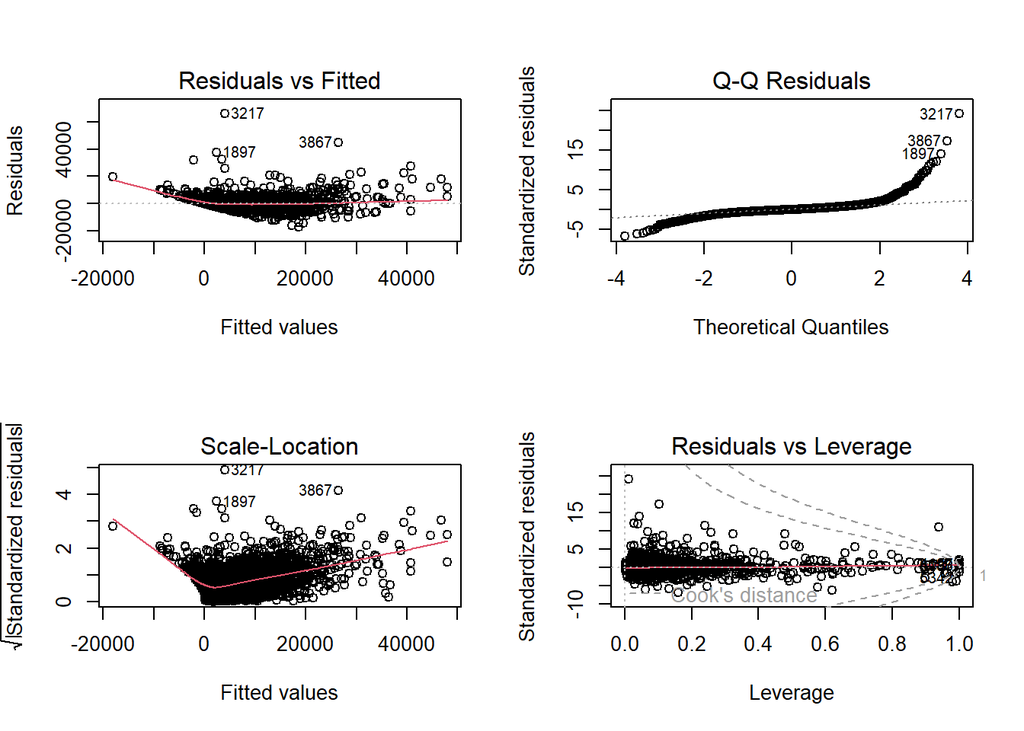

```r
# Diagnostics: Check residuals for any patterns
par(mfrow = c(2, 2))  # Multiple plots in one window
plot(full_model)
```

```r
step = stepAIC(full_model, trace = FALSE, direction = "backward")
step$anova
```

| Step | Df | Deviance | Resid. Df | Resid. Dev | AIC |
| --- | --- | --- | --- | --- | --- |
|  | NA | NA | 6727 | 50752178061 | 112398.0 |
| - horsepower:type_of_drive | 2 | 489335.8 | 6729 | 50752667397 | 112394.1 |
| - horsepower:A_C | 2 | 16033793.4 | 6731 | 50768701190 | 112392.3 |
| - engine_capacity:color | 17 | 230316433.5 | 6748 | 50999017624 | 112390.3 |
| - car_mileage:color | 17 | 210007501.8 | 6765 | 51209025126 | 112385.4 |
| - engine_capacity:doors | 1 | 3790831.3 | 6766 | 51212815957 | 112383.9 |
| - horsepower:doors | 1 | 3443404.6 | 6767 | 51216259361 | 112382.4 |
| - age:post_info | 21 | 302811494.1 | 6788 | 51519070856 | 112382.1 |

```r
step$call
```

```
## lm(formula = price ~ age + car_mileage + engine_capacity + horsepower +
##     post_info + A_C + seats_amount + color + type_of_drive +
##     doors + fuel + car_type + gearbox + age:A_C + age:seats_amount +
##     age:color + age:type_of_drive + age:doors + age:fuel + age:car_type +
##     age:gearbox + car_mileage:post_info + car_mileage:A_C + car_mileage:seats_amount +
##     car_mileage:type_of_drive + car_mileage:doors + car_mileage:fuel +
##     car_mileage:car_type + car_mileage:gearbox + engine_capacity:post_info +
##     engine_capacity:A_C + engine_capacity:seats_amount + engine_capacity:type_of_drive +
##     engine_capacity:fuel + engine_capacity:car_type + engine_capacity:gearbox +
##     horsepower:post_info + horsepower:seats_amount + horsepower:color +
##     horsepower:fuel + horsepower:car_type + horsepower:gearbox,
##     data = clean_data)
```

```r
final_model <- lm(formula = price ~ age + car_mileage + engine_capacity + horsepower +
     post_info + A_C + seats_amount + color + type_of_drive +
     doors + fuel + gearbox + age:A_C + age:seats_amount +
     age:color + age:type_of_drive + age:doors + age:fuel +
     age:gearbox + car_mileage:post_info + car_mileage:A_C + car_mileage:seats_amount +
     car_mileage:type_of_drive + car_mileage:doors + car_mileage:fuel +
     car_mileage:gearbox + engine_capacity:post_info +
     engine_capacity:A_C + engine_capacity:seats_amount + engine_capacity:type_of_drive +
     engine_capacity:fuel + engine_capacity:gearbox +
     horsepower:post_info + horsepower:seats_amount + horsepower:color +
     horsepower:fuel + horsepower:gearbox,
     data = clean_data)

# Check for multicollinearity (VIF - Variance Inflation Factor)
#print(vif(final_model))

summary(final_model)
```

```
##
## Call:
## lm(formula = price ~ age + car_mileage + engine_capacity + horsepower +
##     post_info + A_C + seats_amount + color + type_of_drive +
##     doors + fuel + gearbox + age:A_C + age:seats_amount + age:color +
##     age:type_of_drive + age:doors + age:fuel + age:gearbox +
##     car_mileage:post_info + car_mileage:A_C + car_mileage:seats_amount +
##     car_mileage:type_of_drive + car_mileage:doors + car_mileage:fuel +
##     car_mileage:gearbox + engine_capacity:post_info + engine_capacity:A_C +
##     engine_capacity:seats_amount + engine_capacity:type_of_drive +
##     engine_capacity:fuel + engine_capacity:gearbox + horsepower:post_info +
##     horsepower:seats_amount + horsepower:color + horsepower:fuel +
##     horsepower:gearbox, data = clean_data)
##
## Residuals:
##    Min     1Q Median     3Q    Max
## -16962  -1161   -192    827  66821
##
## Coefficients: (5 not defined because of singularities)
##                                                  Estimate Std. Error t value
## (Intercept)                                     6.119e+03  1.919e+03   3.189
## age                                            -9.761e+02  6.110e+01 -15.977
## car_mileage                                    -1.108e-02  1.562e-03  -7.096
## engine_capacity                                 7.809e-01  8.905e-01   0.877
## horsepower                                      1.680e+02  1.272e+01  13.207
## post_infoposted 2 weeks ago                     2.315e+01  7.549e+02   0.031
## post_infoposted 3 days ago                      1.018e+03  1.066e+03   0.955
## post_infoposted 3 weeks ago                     1.052e+02  7.693e+02   0.137
## post_infoposted 4 days ago                     -9.277e+01  1.025e+03  -0.090
## post_infoposted 4 weeks ago                     2.399e+02  1.099e+03   0.218
## post_infoposted 5 days ago                     -8.316e+01  9.377e+02  -0.089
## post_infoposted 6 days ago                     -2.095e+02  1.088e+03  -0.193
## post_infoposted a week ago                      5.317e+02  7.379e+02   0.721
## post_infoposted today                          -7.256e+00  1.013e+03  -0.007
## post_infoupdated 2 days ago                     1.115e+03  1.098e+03   1.016
## post_infoupdated 2 weeks ago                   -1.100e+03  1.059e+03  -1.038
## post_infoupdated 3 days ago                    -6.228e+03  1.257e+03  -4.954
## post_infoupdated 3 weeks ago                    8.875e+02  1.103e+03   0.805
## post_infoupdated 4 days ago                    -1.097e+03  1.195e+03  -0.918
## post_infoupdated 4 weeks ago                    1.181e+03  2.232e+03   0.529
```

[output cut: 488 more lines]

```
## horsepower:fuelhybrid                          0.287584
## horsepower:fuelmethane                         0.920851
## horsepower:fuelpetrol                          4.65e-05 ***
## horsepower:fuelpetrol + gas                    0.788975
## horsepower:gearboxmanual, 4 speeds             0.003419 **
## horsepower:gearboxmanual, 5 speeds             1.14e-14 ***
## horsepower:gearboxmanual, 6 speeds             1.28e-07 ***
## horsepower:gearboxmanual, multiple speeds      0.001310 **
## horsepower:gearboxsemi-automatic               0.038211 *
## ---
## Signif. codes:  0 '***' 0.001 '**' 0.01 '*' 0.05 '.' 0.1 ' ' 1
##
## Residual standard error: 2863 on 6823 degrees of freedom
## Multiple R-squared:  0.7522, Adjusted R-squared:  0.743
## F-statistic: 82.17 on 252 and 6823 DF,  p-value: < 2.2e-16
```

Diagnostics:

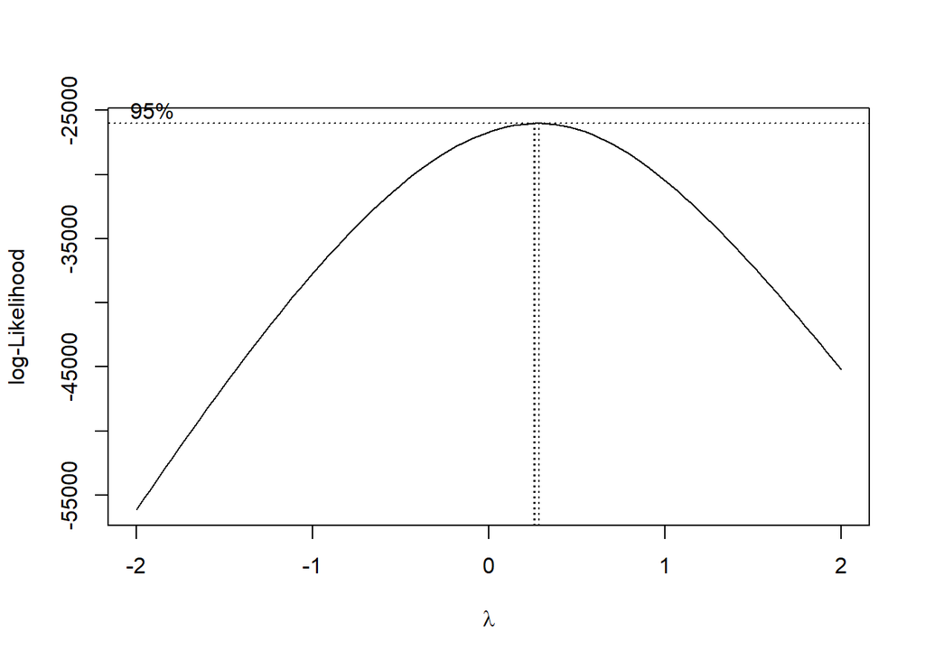

```r
# Load necessary library
library(MASS)

# Box-Cox transformation for `price`
boxcox_result <- boxcox(final_model, lambda = seq(-2, 2, by = 0.1), main = "Box-Cox Transformation")
```

```r
# Extract the best lambda (transformation parameter)
best_lambda <- boxcox_result$x[which.max(boxcox_result$y)]
cat("Best lambda:", best_lambda, "\n")
```

```
## Best lambda: 0.2626263
```

```r
# Apply transformation based on best lambda
if (abs(best_lambda) < 0.1) {
  clean_data$price <- log(clean_data$price)
  cat("Applied log transformation to `price`.\n")
} else {
  clean_data$price <- (clean_data$price^best_lambda - 1) / best_lambda
  cat("Applied Box-Cox transformation with lambda =", best_lambda, "to `price`.\n")
}
```

```
## Applied Box-Cox transformation with lambda = 0.2626263 to `price`.
```

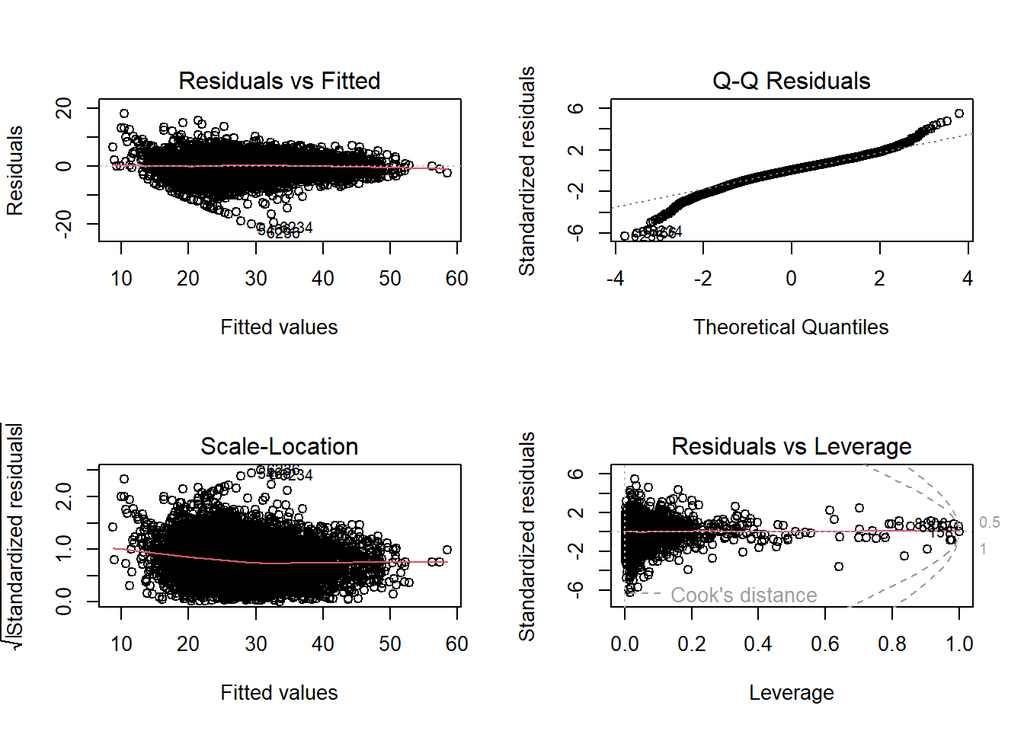

```r
n <- nrow(clean_data)
cooks_d <- cooks.distance(final_model)
cooks_threshold <- 4/n #might need to change
influential_points <- which(cooks_d > cooks_threshold)
clean_data <- clean_data[-which(cooks_d > cooks_threshold), ]

# Refit the model after transformation
final_model <- lm(formula = price ~ age + car_mileage + engine_capacity + horsepower +
                     post_info + A_C + seats_amount + color + type_of_drive +
                     doors + fuel + gearbox + age:A_C + age:seats_amount +
                     age:color + age:type_of_drive + age:doors + age:fuel +
                     age:gearbox + car_mileage:post_info + car_mileage:A_C + car_mileage:seats_amount +
                     car_mileage:type_of_drive + car_mileage:doors + car_mileage:fuel +
                     car_mileage:gearbox + engine_capacity:post_info +
                     engine_capacity:A_C + engine_capacity:seats_amount + engine_capacity:type_of_drive +
                     engine_capacity:fuel + engine_capacity:gearbox +
                     horsepower:post_info + horsepower:seats_amount + horsepower:color +
                     horsepower:fuel + horsepower:gearbox,
                   data = clean_data)
#par(mfrow = c(2, 2))  # Multiple plots in one window
#plot(final_model)

# Residual diagnostics plots
par(mfrow = c(2, 2))
plot(final_model)
```

```r
# Histogram of residuals
hist(resid(final_model), breaks = 30, main = "Histogram of Residuals",
     xlab = "Residuals", col = "lightblue")

# Q-Q plot
qqnorm(resid(final_model), main = "Q-Q Plot")
qqline(resid(final_model), col = "red", lty = 2)

# Load the `lmtest` library
library(lmtest)
# Perform Breusch-Pagan test
bp_test <- bptest(final_model)
print(bp_test)
```

```
##
##  studentized Breusch-Pagan test
##
## data:  final_model
## BP = 576.74, df = 246, p-value < 2.2e-16
```

```r
# Interpretation
if (bp_test$p.value < 0.05) {
  cat("Heteroscedasticity detected (p-value < 0.05). Consider WLS.\n")
} else {
  cat("No significant heteroscedasticity detected.\n")
}
```

```
## Heteroscedasticity detected (p-value < 0.05). Consider WLS.
```

[figure not shown]

```r
# validation data
#validation_data <- car_price_data
validation_data[validation_data == ""] <- NA
sum(is.na(car_price_data$emission_class))  # Number of rows with missing emission_class
```

```
## [1] 0
```

```r
validation_data <- car_price_data[is.na(car_price_data$emission_class) &
                                  rowSums(is.na(car_price_data)) == 1, ]

validation_data$age <- 2024 - validation_data$year
validation_data$horsepower<-gsub(pattern = "^(\\d+) HP.*", replacement = "\\1", validation_data$horsepower)
validation_data$horsepower<-as.numeric(validation_data$horsepower)

names(validation_data) <- gsub(pattern = "\\.\\..*", replacement = "", names(validation_data))

# List of all categorical variables
categorical_vars <- c("post_info", "A_C", "emission_class", "seats_amount",
                      "color", "type_of_drive", "doors", "fuel",
                      "car_type", "gearbox")

for (var in categorical_vars) {
  if (!is.factor(validation_data[[var]])) {
      validation_data[[var]] <- as.factor(validation_data[[var]])
  }
}
validation_data <- validation_data[, names(validation_data) != "emission_class"]

# Specify the columns to exclude
#columns_to_exclude <- c("car_mileage", "column_name2", "column_name3")

# Exclude these columns from validation_data
#validation_data <- validation_data[, !(names(validation_data) %in% columns_to_exclude)]

# Step 1: Obtain predicted values for the validation set
model_without_emission <- lm(update(formula(final_model), . ~ . - emission_class), data = clean_data)
pred_validation <- predict(model_without_emission, newdata = validation_data)

# Step 2: Compute prediction errors
# Assuming 'price' is the dependent variable in validation_data
delta_validation <- validation_data$price - pred_validation

# Step 3: Compute MSPE
delta_validation <- validation_data$price - pred_validation
MSPE <- sum(delta_validation^2) / length(delta_validation)

# Step 4: Print MSPE
MSPE
```

```
## [1] NaN
```

```r
sum(is.na(pred_validation))  # Count of missing predicted values
```

```
## [1] 0
```

```r
sum(is.na(validation_data$price))  # Count of missing actual values
```

```
## [1] 0
```

```r
nrow(validation_data)
```

```
## [1] 0
```

```r
delta_validation <- validation_data$price - pred_validation
delta_validation <- na.omit(delta_validation)  # Remove missing errors
MSPE <- sum(delta_validation^2) / length(delta_validation)
MSPE
```

```
## [1] NaN
```

WLS is a next step since we failed heteroelasticity (equal variance) assumption. This means that we’d include a weight vector when fitting the model, and hopefully this would fix the equal variance problem.

I don’t really want to keep this code, but leaving this here in case someone wants to work with it.

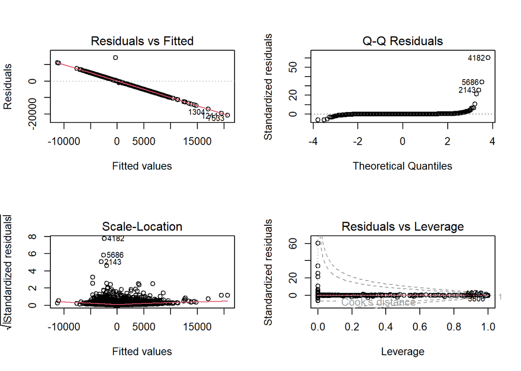

```r
# Calculate weights based on residuals
weights <- 1 / (resid(final_model)^2)

# Fit WLS model
wls_model <- lm(formula = price ~ age + car_mileage + engine_capacity + horsepower +
                   post_info + A_C + seats_amount + color + type_of_drive +
                   doors + fuel + gearbox + age:A_C + age:seats_amount +
                   age:color + age:type_of_drive + age:doors + age:fuel +
                   age:gearbox + car_mileage:post_info + car_mileage:A_C + car_mileage:seats_amount +
                   car_mileage:type_of_drive + car_mileage:doors + car_mileage:fuel +
                   car_mileage:gearbox + engine_capacity:post_info +
                   engine_capacity:A_C + engine_capacity:seats_amount + engine_capacity:type_of_drive +
                   engine_capacity:fuel + engine_capacity:gearbox +
                   horsepower:post_info + horsepower:seats_amount + horsepower:color +
                   horsepower:fuel + horsepower:gearbox,
                 data = clean_data, weights = weights)

# Check diagnostics for the WLS model
par(mfrow = c(2, 2))
plot(wls_model)
```

[from here on is a load of garbage :( if you think you can help fix it, you’re more than welcome. Though, it might be easier to just use this as code reference

-Rebecca]

# dw about for now

## Data Analysis

Now, we want to take a look at the distributions of our data, to see if there are any peculiarities that we should be aware of. For continuous data: **age**, **horsepower**, **car mileage**, and **engine capacity**, we examine their violin plots:

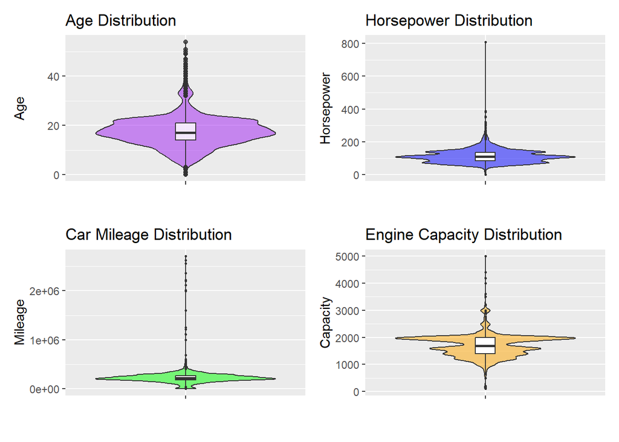

```r
non_empty_age <- clean_data[!is.na(clean_data$age) & !is.na(clean_data$age), ]

age_graph <- ggplot(non_empty_age, aes(x = "", y = age)) +
  geom_violin(fill = "purple", alpha = 0.5, trim=TRUE) +
  geom_boxplot(width = 0.1, alpha = 0.8) +
  labs(title = "Age Distribution", y = "Age", x = "")

non_empty_hp <- data.frame(horsepower =
                             as.integer(clean_data$horsepower[clean_data$horsepower != ""]))

horsepower_graph <- ggplot(non_empty_hp, aes(x = "", y = horsepower)) +
  geom_violin(fill = "blue", alpha = 0.5) +
  geom_boxplot(width = 0.1, fill = "white", outlier.size = 0.5) +
  labs(title = "Horsepower Distribution", y = "Horsepower", x = "")

non_empty_cm <- data.frame(car_mileage =
                             as.integer(clean_data$car_mileage[clean_data$car_mileage != ""]))

# Plot for "car_mileage"
car_mileage_graph <- ggplot(clean_data, aes(x = "", y = car_mileage)) +
  geom_violin(fill = "green", alpha = 0.5) +
  geom_boxplot(width = 0.1, fill = "white", outlier.size = 0.5) +
  labs(title = "Car Mileage Distribution", y = "Mileage", x = "")

non_empty_ec <- data.frame(engine_capacity =
                             as.integer(clean_data$engine_capacity[clean_data$engine_capacity != ""]))

# Plot for "engine_capacity"
engine_capacity_graph <- ggplot(clean_data, aes(x = "", y = engine_capacity)) +
  geom_violin(fill = "orange", alpha = 0.5) +
  geom_boxplot(width = 0.1, fill = "white", outlier.size = 0.5) +
  labs(title = "Engine Capacity Distribution", y = "Capacity", x = "")

all_plots <- age_graph + horsepower_graph + car_mileage_graph + engine_capacity_graph +
  plot_layout(ncol =2)
print(all_plots)
```

## Correlation Analysis

[Note from Rebecca (last person to work on this): this is a little broken right now.

- need to modify the correlation chart to get rid of some useless variables like views
- heatmap is not working I think bc there’s a bunch of outliers in dataset. Going to clean out outliers first, then I’ll get back to heatmap ]

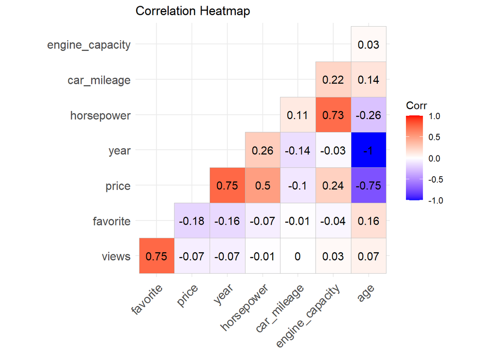

```r
numeric_data <- clean_data[sapply(clean_data, is.numeric)]
cor_matrix <- cor(numeric_data, use = "complete.obs")

ggcorrplot(
  cor_matrix,
  method = "square",
  type = "lower",
  lab = TRUE,
  title = "Correlation Heatmap",
  colors = c("blue", "white", "red")
)
```

[figure not shown]

```r
clean_data$log_horsepower <- log10(as.integer(clean_data$horsepower))
clean_data$log_car_mileage <- log10(as.integer(clean_data$car_mileage))

ggplot(clean_data, aes(x = log_horsepower, y = log_car_mileage)) +
  geom_bin2d(binwidth = c(10, 500)) +  # Adjust bin width for better visualization
  scale_fill_gradient(low = "blue", high = "yellow") +  # Density color scale
  labs(title = "Density of Horsepower vs. Car Mileage",
       x = "Horsepower", y = "Car Mileage", fill = "Count") +
  theme_minimal()
```